# An Introduction to Bayesian Inference using R Interfaces to Stan, Part I

June 27, 2016

## Installation

- If you have not installed the **rstan** R package yet, please follow the steps at https://github.com/stan-dev/rstan/wiki/RStan-Getting-Started because you need Xcode on a Mac, RTools on Windows, or build-essential on Linux
- If you have installed the **rstan** R package, please make sure `packageVersion("rstan")` is 2.10.1.
- In either case, please verify that a Stan program compiles and runs with

```r
example("stan_model", package = "rstan", run.dontrun = TRUE)
```

- Also, verify that `packageVersion("rstanarm")` is 2.10.1; otherwise execute

```r
install.packages("rstanarm", repos = "https://cloud.r-project.org", dependencies = TRUE)
```

```
* If you have Windows and R version less than 3.3.x, you may have to add `type = "source"`
```

## Outline

1. Probability background, Markov Chain Monte Carlo, rstanarm example
2. Break from 2:15 to 2:30
3. Hierarchical model example, Stan language, writing Stan programs

## Obligatory Disclosure

- I am an employee of Columbia University, which has received several research grants to develop Stan
- I am also a cofounder of Stan Group (http://stan.fit), which provides support, consulting, etc. for businesses using Stan
- According to Columbia University policy, any such employee who has any equity stake in, a title (such as officer or director) with, or is expected to earn at least \(\$5,000.00\) per year from a private company is required to disclose these facts in presentations

## What Was the Probability of Brexit?

- If I were to have asked you (a week ago), what is the probability that the British would vote to leave the European Union, what would you have said?
- If everyone could have supplied an answer to that question (a week ago), where did these beliefs about the probability of this event come from?

## Different Perspectives on Probability

| What is the paradigm? | What is fixed? | What is random? | What proportion is important? | What is the conclusion? |
| --- | --- | --- | --- | --- |
| Randomization | \({y_1, y_2, \dots, y_N}\) | Treatment assignment | \(p\)-value for null: ATE \(= 0\)? | ATE \(\neq 0\) |
| Frequentist | \(Y\), \(\boldsymbol{\theta}\), \(N\) | Sample inclusion | \(\theta \in\) confidence intervals (plural) | Something basically Bayesian |
| Supervised learning | \({y_1, y_2, \dots, y_N}\) | Training / testing inclusion | Correctly classified outcomes in testing data | Some procedure predicts best |
| Bayesian | \({y_1, y_2, \dots, y_N}\), \(\boldsymbol{\theta}\) | Beliefs about \(\boldsymbol{\theta}\) | Posterior draws of \(\theta \in \left(a,b\right)\) | Decision or action |

## Two Justifications for Bayes Rule

1. \(f\left(\mathbf{y}\right) \times f\left(\boldsymbol{\theta} | \mathbf{y}\right) = f\left(\boldsymbol{\theta}, \mathbf{y}\right) = f\left(\boldsymbol{\theta}\right) \times f\left(\mathbf{y} | \boldsymbol{\theta}\right) \implies f\left(\boldsymbol{\theta} | \mathbf{y}\right) = \frac{f\left(\boldsymbol{\theta}\right) \times f\left(\mathbf{y} | \boldsymbol{\theta}\right)}{f\left(\mathbf{y}\right)}\) where \(\mathbf{y} = \{y_1, y_2 \dots y_N\}\) and \(f\left(\cdot\right)\) is a PDF so \(f\left(\cdot\right) \geq 0\) & \(\int f\left(u\right)du = 1\)
   - \(f\left(\boldsymbol{\theta}\right)\) represents what someone **believes** about \(\boldsymbol{\theta}\) prior to observing \(\mathbf{y}\)
   - \(f\left(\boldsymbol{\theta} | \mathbf{y}\right)\) represents what someone **believes** about \(\boldsymbol{\theta}\) after observing \(\mathbf{y}\)
   - \(f\left(\mathbf{y} | \boldsymbol{\theta}\right)\) is the likelihood function, a function of \(\boldsymbol{\theta}\) for an observed \(\mathbf{y}\)
   - \(f\left(\mathbf{y}\right) = \int \cdots \int \int f\left(\boldsymbol{\theta}\right) f\left(\mathbf{y} | \boldsymbol{\theta}\right) d\theta_1 d\theta_2 \dots d\theta_K = \mathbb{E}_{\boldsymbol{\theta}}f\left(\mathbf{y} | \boldsymbol{\theta}\right)\)
2. \(f\left(\boldsymbol{\theta} | \mathbf{y}\right)\) is the unique function that minimizes the sum of
   - Penalty: Kullback-Leibler divergence to \(f\left(\boldsymbol{\theta}\right)\)
   - Expected misfit: \(\mathbb{E}_{\boldsymbol{\theta}}\left[-\ln f\left(\mathbf{y} | \boldsymbol{\theta}\right)\right]\)

## Markov Chain Monte Carlo

- Even if \(f\left(\mathbf{y}\right)\) could be calculated, you would have to do *another* K-dimensional integral to obtain something like \(\mathbb{E}\left[\theta_k | \mathbf{y}\right]\)
- So we draw randomly \(S\) times from the posterior distribution — which does not require knowing \(f\left(\mathbf{y}\right)\) — and estimate \(\mathbb{E}\left[\theta_k | \mathbf{y}\right]\) with \(\frac{1}{S}\sum_{s=1}^S{\tilde{\theta}_k^{[s]}}\)
- There is no way to draw independently from most posterior distributions
- The price to be paid for relying on Markov Chain Monte Carlo (MCMC) to draw from a posterior distribution is that the draws are **not** independent
- The degree of dependence in a MCMC algorithm governs how badly \(\frac{1}{S}\sum_{s=1}^S{g\left(\widetilde{\boldsymbol{\theta}}^{[s]}\right)}\) estimates \(\mathbb{E}g\left(\boldsymbol{\theta}\right) | \mathbf{y}\) for finite \(S\)
- Effective Sample Size is a concept like that in complex survey design and is defined as the number of *independent* draws that would estimate a posterior mean with the same precision as the \(S\) *dependent* draws you do have

## A Markov Process with Severe Dependence

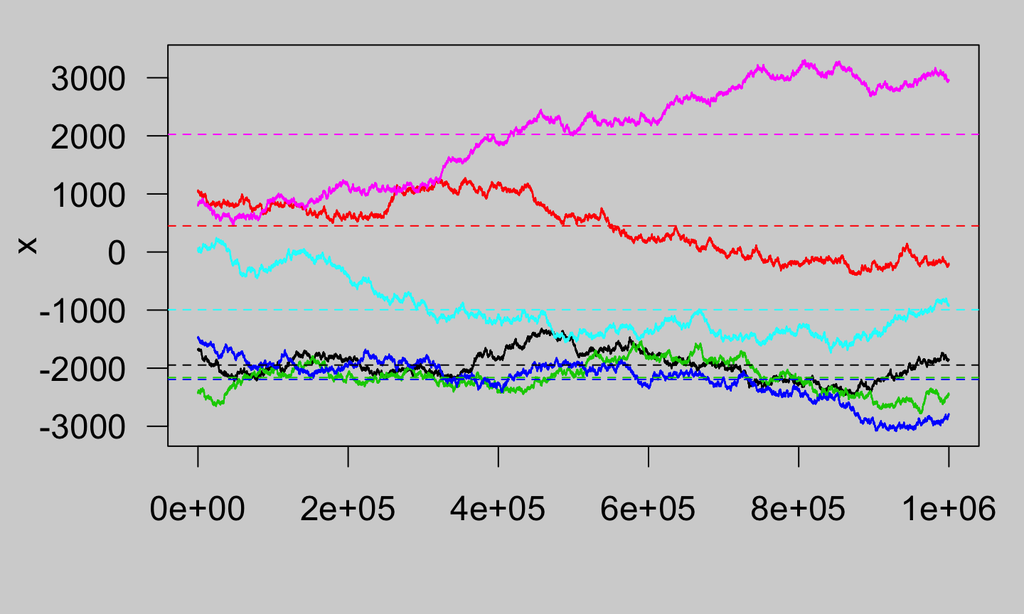

```r
par(mar = c(4,4,1,1) + .1, las = 1, bg = "lightgrey")
x <- sapply(1:6, FUN = function(i) arima.sim(model = list(ar = 0.9999999), n = 10^6))
matplot(x, type = "l", col = 1:6, lty = 1)
for (j in 1:ncol(x)) abline(h = mean(x[,j]), col = j, lty = 2)
```

## Why Doesn't Everyone Use Bayesian Methods?

- There are very few useful analytical results
- Traditional commercial software business model does not work for Bayesians:
  - Can't let 1 programmer write generic code that all paying researchers use
  - Posterior distribution depends not just on the researcher's data but on the prior beliefs of the researcher, which must be encoded somehow
- To express your prior beliefs using probability distributions, you need to know the functional characteristics of lots of probability distributions
- Drawing from an entire probability distribution is a much more ambitious task than finding a optimal point and takes a lot longer
- Many researchers were frustrated by the BUGS family of software
- Harder to publish a Bayesian analysis in an applied journal

## What is Stan and How Does It Help?

- Includes a probabalistic programming language
  - The **rstanarm**, **brms**, and **rethinking** R packages provide code to specify some statistical models — with a limited choice of prior distributions — that can be mapped into the Stan language
- Includes new Hamiltonian Monte Carlo (HMC) algorithms
  - HMC is to MCMC as BFGS is to optimization
  - HMC is aided by the gradient of the posterior distribution wrt \(\boldsymbol{\theta}\)
  - Dependence between consecutive draws is minimal
- Includes a matrix and scalar math library that supports autodifferentiation
- Includes interfaces from R and other high-level software
- Includes (not Stan specific) post-estimation R functions of MCMC output
- Includes a large community of users and many developers

## Overview of Hamiltonian Monte Carlo

- Since the early 1990s, most MCMC uses Gibbs updates when feasible and falls back to something more general otherwise
  - Gibbs entails drawing \(\theta_k\) from its "full-conditional distribution": \(\theta_k | \boldsymbol{\theta}_{-k}, \mathbf{y}\)
  - "Something more general" includes slice sampling, Metropolis-Hastings, etc., which is needed when the full-conditional distribution of \(\theta_k\) is not known in closed form
- If Gibbs updates are feasible, they are easy to code and fast to execute but are *statistically* inefficient because the dependence between draws is high
- HMC differs from Gibbs in that all elements of \(\boldsymbol{\theta}\) are updated simultaneously
- H stands for Hamiltonian, which is a physics framework for how a particle \(\left(\boldsymbol{\theta}\right)\) moves through an unbounded frictionless space

## Example of Drawing from a Multivariate Normal

- \(\mathbf{y} \thicksim \mathcal{N}_{250}\left(\mathbf{0}, \boldsymbol{\Sigma}\right)\) where \(\boldsymbol{\Sigma}\) is ill-conditioned but focus on just two dimensions
- Do 1 million draws w/ Random Walk Metropolis & Gibbs, thinning by \(1000\)
- Do 1000 draws with the NUTS algorithm in Stan and 1000 independent draws

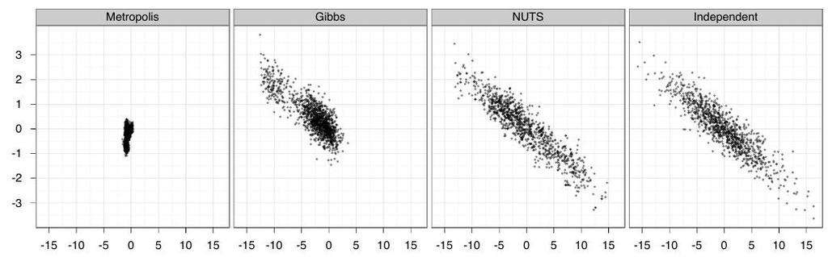

Comparison of MCMC Samplers